# Lab 10: Filtering Data

## Pick a dataset

Pick a dataset (feel free to delete the others from the Rmd file if you would like), and work on the instructions in the next section.

## Instructions

This lab is similar to the last. You’ll pick a dataset and then generate an analysis of that data using data visualizations. The difference here is that instead of a single plot, I would like you to construct 3-4 plots that together tell a linear story. Each plot should be separated by a sentence or two describing what the viewer should take away from the plot. Try to keep the plots similar in some way; perhaps each simply highlights a different subset of the data but has the same underlying layers.

Notice that each of the datasets for today are larger than you will probably be able to use. You will need to filter the data to a particular team, year, subset of curse words. You may further filter the data to highlight an even smaller subset of the data within each plot.

## Analysis

```
## # A tibble: 6,440 x 7
##                   date replies retweets favorites        user party state
##                 <dttm>   <int>    <int>     <int>       <chr> <chr> <chr>
##  1 2017-10-20 01:50:00      31      313       288 SenBobCasey     D    PA
##  2 2017-10-20 01:48:00     103      679      1285 SenBobCasey     D    PA
##  3 2017-10-19 22:53:00      53      225       267 SenBobCasey     D    PA
##  4 2017-10-19 21:42:00      95      783      1155 SenBobCasey     D    PA
##  5 2017-10-19 17:42:00      44      141       657 SenBobCasey     D    PA
##  6 2017-10-19 17:41:00      99      440      1856 SenBobCasey     D    PA
##  7 2017-10-19 14:51:00       7       33       232 SenBobCasey     D    PA
##  8 2017-10-18 20:01:00      46      130       327 SenBobCasey     D    PA
##  9 2017-10-18 20:00:00      10       65       278 SenBobCasey     D    PA
## 10 2017-10-18 19:58:00      12       69       229 SenBobCasey     D    PA
## # ... with 6,430 more rows
```

```
## # A tibble: 3,296 x 7
##                   date replies retweets favorites        user party state
##                 <dttm>   <int>    <int>     <int>       <chr> <chr> <chr>
##  1 2017-10-20 01:50:00      31      313       288 SenBobCasey     D    PA
##  2 2017-10-20 01:48:00     103      679      1285 SenBobCasey     D    PA
##  3 2017-10-19 22:53:00      53      225       267 SenBobCasey     D    PA
##  4 2017-10-19 21:42:00      95      783      1155 SenBobCasey     D    PA
##  5 2017-10-19 17:42:00      44      141       657 SenBobCasey     D    PA
##  6 2017-10-19 17:41:00      99      440      1856 SenBobCasey     D    PA
##  7 2017-10-19 14:51:00       7       33       232 SenBobCasey     D    PA
##  8 2017-10-18 20:01:00      46      130       327 SenBobCasey     D    PA
##  9 2017-10-18 20:00:00      10       65       278 SenBobCasey     D    PA
## 10 2017-10-18 19:58:00      12       69       229 SenBobCasey     D    PA
## # ... with 3,286 more rows
```

```
## # A tibble: 1,485 x 7
##                   date replies retweets favorites        user party state
##                 <dttm>   <int>    <int>     <int>       <chr> <chr> <chr>
##  1 2017-10-20 01:50:00      31      313       288 SenBobCasey     D    PA
##  2 2017-10-20 01:48:00     103      679      1285 SenBobCasey     D    PA
##  3 2017-10-19 22:53:00      53      225       267 SenBobCasey     D    PA
##  4 2017-10-19 21:42:00      95      783      1155 SenBobCasey     D    PA
##  5 2017-10-19 17:42:00      44      141       657 SenBobCasey     D    PA
##  6 2017-10-19 17:41:00      99      440      1856 SenBobCasey     D    PA
##  7 2017-10-19 14:51:00       7       33       232 SenBobCasey     D    PA
##  8 2017-10-18 20:01:00      46      130       327 SenBobCasey     D    PA
##  9 2017-10-18 20:00:00      10       65       278 SenBobCasey     D    PA
## 10 2017-10-18 19:58:00      12       69       229 SenBobCasey     D    PA
## # ... with 1,475 more rows
```

```
## # A tibble: 154 x 7
##                   date replies retweets favorites        user party state
##                 <dttm>   <int>    <int>     <int>       <chr> <chr> <chr>
##  1 2017-10-20 01:50:00      31      313       288 SenBobCasey     D    PA
##  2 2017-10-20 01:48:00     103      679      1285 SenBobCasey     D    PA
##  3 2017-10-19 22:53:00      53      225       267 SenBobCasey     D    PA
##  4 2017-10-19 21:42:00      95      783      1155 SenBobCasey     D    PA
##  5 2017-10-19 17:42:00      44      141       657 SenBobCasey     D    PA
##  6 2017-10-19 17:41:00      99      440      1856 SenBobCasey     D    PA
##  7 2017-10-19 14:51:00       7       33       232 SenBobCasey     D    PA
##  8 2017-10-18 20:01:00      46      130       327 SenBobCasey     D    PA
##  9 2017-10-18 20:00:00      10       65       278 SenBobCasey     D    PA
## 10 2017-10-18 19:58:00      12       69       229 SenBobCasey     D    PA
## # ... with 144 more rows
```

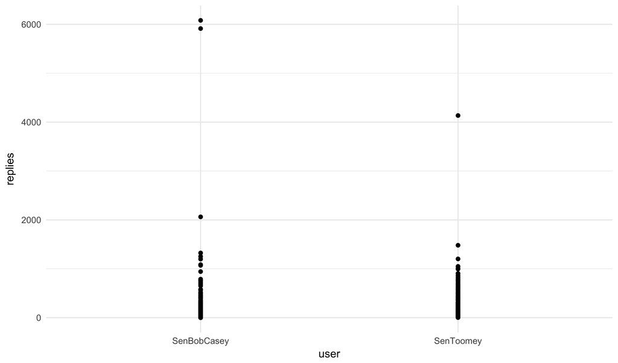

This graph is highlighting the replies in green for each Pennsylvania Senator after June 1st, 2017.

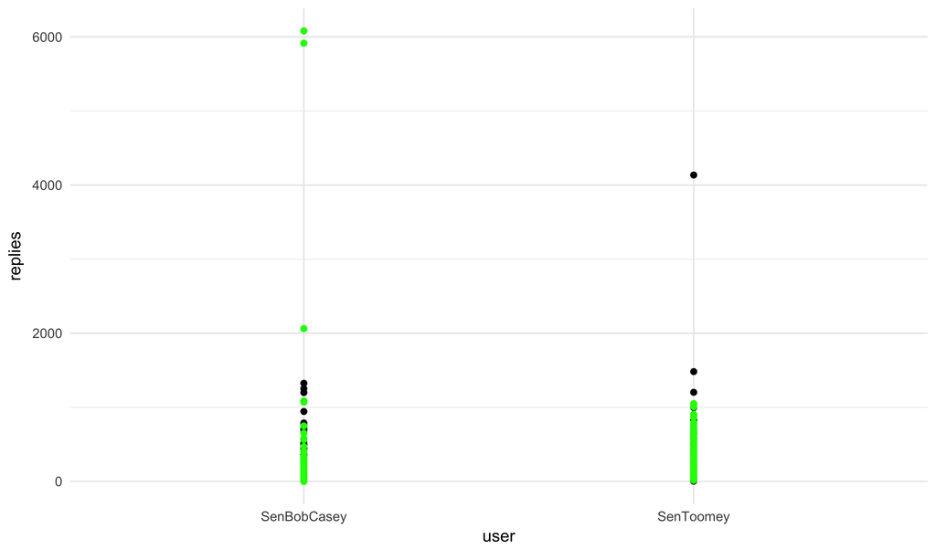

This graph is highlighting the replies in blue for each Senator in October 2017.

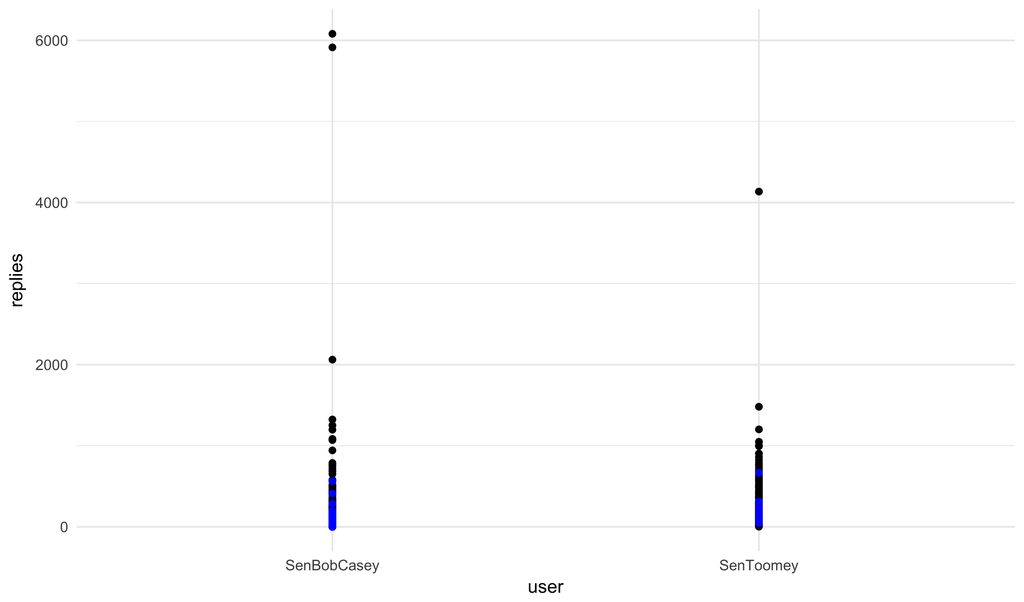